# NNs for Classification Using `neuralnet` R Package

Rishikesh Yadav

2024-08-08

## Introduction

In this document, we will construct a basic neural network architecture using the `neuralnet` package in R. We will cross-check our implemented code for NNs from scarcth. You may look at the file `NNs-for-classification_from_scratch.Rmd`

## Install and Load Necessary Packages

We start by installing and loading the necessary packages.

```r
library(neuralnet)
library(ggplot2)
```

## Generate Synthetic Data

We generate synthetic data for this example. The data consists of two input features (`x1` and `x2`) and a binary target variable (`y`).

```r
set.seed(42)
n <- 1000
x1 <- rnorm(n)
x2 <- rnorm(n)
y <- ifelse(x1^2 + x2^2 + rnorm(n) > 1.5, 1, 0)
data <- data.frame(x1 = x1, x2 = x2, y = y)
```

## Split Data into Training and Test Sets

We split the data into training and test sets. 70% of the data is used for training and 30% for testing.

```r
set.seed(42)
train_indices <- sample(1:n, size = 0.7 * n)
train_data <- data[train_indices, ]
test_data <- data[-train_indices, ]
```

## Define Neural Network Formula

We define the formula for the neural network. In this case, we want to predict `y` using `x1` and `x2`.

```r
formula <- y ~ x1 + x2
```

## Train the Neural Network

We train the neural network using the `neuralnet` package. We specify one hidden layer with 10 neurons and use the sigmoid activation function.

```r
set.seed(42)
nn <- neuralnet(formula,
                data = train_data,
                hidden = c(10),
                linear.output = FALSE,
                stepmax = 1e6,
                learningrate = 0.1)
```

## Plot the Neural Network Architecture

We plot the neural network to visualize its structure.

```r
plot(nn)
```

[output not shown]

## Forward Propagation

We define the forward propagation function, which computes the weighted sum of inputs and applies the activation function.

```r
forward_propagation <- function(X, weights, biases, activation_function) {
  Z <- X %*% weights + biases
  A <- activation_function(Z)
  return(list(Z = Z, A = A))
}

sigmoid <- function(z) {
  1 / (1 + exp(-z))
}
```

## Evaluate the Model on Test Data

We evaluate the trained model on the test data and calculate the accuracy.

```r
test_X <- as.matrix(test_data[, c("x1", "x2")])
predictions <- compute(nn, test_X)$net.result
predicted_classes <- ifelse(predictions > 0.5, 1, 0)

confusion_matrix <- table(test_data$y, predicted_classes)
accuracy <- sum(diag(confusion_matrix)) / sum(confusion_matrix)
print(confusion_matrix)
```

```
##    predicted_classes
##       0   1
##   0 123  21
##   1  45 111
```

```r
print(paste("Accuracy:", accuracy))
```

```
## [1] "Accuracy: 0.78"
```

## Plot Decision Boundary

We plot the decision boundary of the neural network to visualize how it classifies the data.

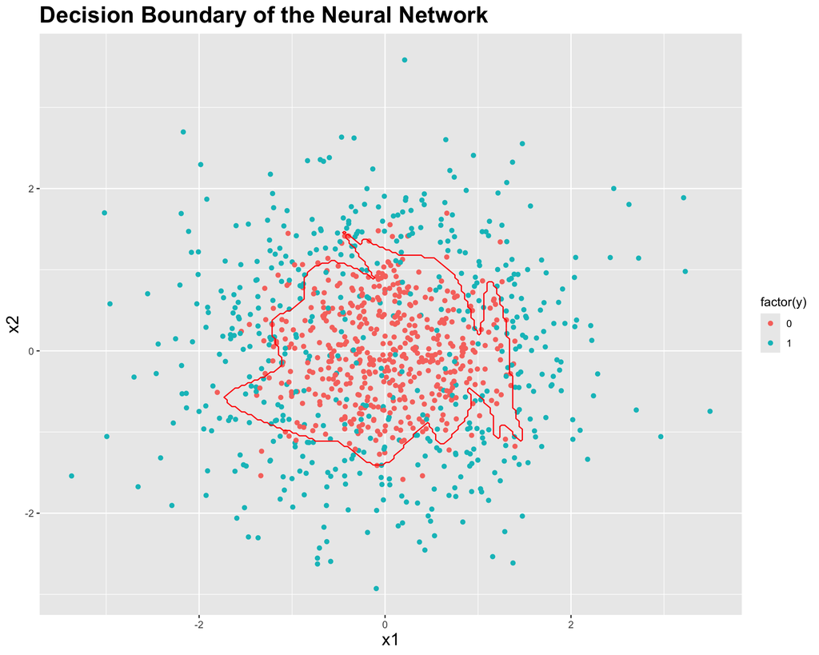

```r
plot_data <- expand.grid(x1 = seq(min(data$x1), max(data$x1), length.out = 200),
                         x2 = seq(min(data$x2), max(data$x2), length.out = 200))
pred_grid <- compute(nn, as.matrix(plot_data))$net.result
plot_data$y <- ifelse(pred_grid > 0.5, 1, 0)

ggplot(data, aes(x = x1, y = x2, color = factor(y))) +
  geom_point() +
  geom_contour(data = plot_data, aes(z = y), breaks = 0.5, color = "red") +
  labs(title = "Decision Boundary of the Neural Network", x = "x1", y = "x2") +
  theme(
    plot.title = element_text(size = 20, face = "bold"),
    axis.title.x = element_text(size = 15),
    axis.title.y = element_text(size = 15)
  )
```

## Conclusion

In this example, we constructed a basic neural network using the `neuralnet` package in R. We covered the essential components of neural networks and demonstrated how to train and evaluate a neural network on synthetic data. The model’s decision boundary was visualized to understand how it classifies the data. Remarkably, the results look very similar to what we achieved in when we code our NNs from scratch. You may look at `NNs-for-classification_from_scratch.R` or `NNs-for-classification_from_scratch.html` for our implemented NNs arcticetires for the classification purposes.